# QPot: An R Package for Stochastic Differential Equation Quasi-Potential Analysis

## Step 3: Local quasi-potential calculation

The next step is to compute a local quasi-potential for each attractor. Because *QPot* deals with two-dimensional systems, attractor will be used synonymously with stable equilibrium or stable limit cycle. A limit cycle will be considered in example 2. For now, suppose that the only attractors are stable equilibrium points, $\mathbf{e}_{si}$, $i=1,\,\ldots,\, n.$ In the example above, $n=2.$ For each stable equilibrium $\mathbf{e}_{si}$, we will compute a local quasi-potential $\Phi_{i}(x,y).$

In order to understand the local quasi-potential, it is useful consider the analogy of a particle traveling according to System @ref(eq:Stochastic). In the context of Example 1, the coordinates of the particle correspond to population densities, and the particle’s path corresponds to how those population densities change over time. The deterministic skeleton of @ref(eq:Stochastic) can be visualized as a force field influencing the particle’s trajectory. Suppose that the particle moves along a path from a stable equilibrium $\mathbf{e}_{si}$ to a point $(x,y)$. If this path does not coincide with a solution of the deterministic skeleton, then the stochastic terms must be doing some work to move the particle along the path. The more work is required, the less likely it is for the path to be a realization of System @ref(eq:Stochastic). $\Phi_{i}(x,y)$ is the amount of work required to traverse the easiest path from $\mathbf{e}_{si}$ to $(x,y)$. Note that $\Phi_{i}(x,y)$ is non-negative, and it is zero at $\mathbf{e}_{si}$.

In the basin of attraction for $\mathbf{e}_{si}$, $\Phi_{i}(x,y)$ has many properties analogous to the potential function for gradient systems. Key among these properties is that the quasi-potential is non-increasing along deterministic trajectories. This means that the quasi-potential can be interpreted as a type of energy surface, and the rolling ball metaphor is still valid. The difference is that, in non-gradient systems, there is an additional component to the vector field that causes trajectories to circulate around level sets of the energy surface. This is discussed in more detail in Step 6, below.

*QPot* calculates quasi-potentials using an adjustment developed by Cameron (2012) to the ordered upwind algorithm (J. A. Sethian and Vladimirsky 2001; James A. Sethian and Vladimirsky 2003). The idea behind the algorithm is to calculate $\Phi_{i}(x,y)$ in ascending order, starting with the known point $\mathbf{e}_{si}$. The result is an expanding area where the solution is known.

Calculating $\Phi_{i}(x,y)$ with the function `QPotential()` requires a text string of the equations and parameter values, the stable equilibrium points, the computation domain, and the mesh size. If the equations do not contain the parameter values, the function `Model2String()` can be used to insert the values into the equations, as presented above. For @ref(eq:ex1), this first means inputting the equations:
$$\begin{aligned}
f_{1}(x,y)&=1.54x\left(1-\frac{x}{10.14}\right)-\frac{x^{2}\,
y}{1+x^{2}}\\
f_{2}(x,y)&=\frac{0.476\, x^{2}\, y}{1+x^{2}}-0.112509\, y^{2}.
\end{aligned}$$

In R:

```r
## If not done in a previous step.
parms.eqn.x <- Model2String(var.eqn.x, parms = model.parms)
## Do not print to screen.
parms.eqn.y <- Model2String(var.eqn.y, parms = model.parms, supress.print = TRUE)
## Could also input the values by hand and use this version.
## parms.eqn.x <- "1.54 * x * (1.0 - (x / 10.14)) - (y * (x^2)) / (1.0 + (x^2))"
## parms.eqn.y <- "((0.476 * (x^2) * y) / (1 + (x^2))) - 0.112509 * (y^2)"
```

The coordinates of the points $\mathbf{e}_{si}$, which were determined in Step 1, are $\mathbf{e}_{s1}=(1.4049,\,2.8081)$ and $\mathbf{e}_{s2}=(4.9040,\,4.0619)$.

```r
eq1.x <- 1.40491
eq1.y <- 2.80808
eq2.x <- 4.9040
eq2.y <- 4.06187
```

Next, the boundaries of the computational domain need to be entered. This domain will be denoted by $\left[Lx_{1},Lx_{2}\right]\times\left[Ly_{1},Ly_{2}\right]$. The ordered-upwind method terminates when the solved area encounters a boundary of this domain. Thus, it is important to choose boundaries carefully. For example, if $\mathbf{e}_{si}$ lies on one of the coordinate axes, one should not use that axis as a boundary because the algorithm will immediately terminate. Instead, one should add padding space. This is important even if the padding space corresponds to physically unrealistic values (e.g., negative population densities). For this example, a good choice of boundaries is: $Lx_{1}=Ly_{1}=-0.5,$ and $Lx_{2}=Ly_{2}=20$. This choice of domain was obtained by examining stream plots of the deterministic skeleton and density plots of stochastic realizations (Figures 1–3). The domain contains all of the deterministic skeleton equilibria, and it encompasses a large area around the regions of phase space visited by stochastic trajectories (Figures 1–3). Note that a small padding space was added to the left and bottom sides of the domain, so that the coordinate axes are not the domain boundaries.

```r
bounds.x <- c(-0.5, 20.0)
bounds.y <- c(-0.5, 20.0)
```

In some cases, it may be desirable to treat boundaries differently in the upwind algorithm. This is addressed below in Section 7.

Finally, the mesh size for the discretization of the domain needs to be specified. Let $N_{x}$ be the number of grid points in the $x$-direction and $N_{y}$ be the number of grid points in the $y$-direction. Note that the horizontal distance between mesh points is $h_{x}=\frac{Lx_{2}-Lx_{1}}{N_{x}}$, and the vertical distance between mesh points is $h_{y}=\frac{Ly_{2}-Ly_{1}}{N_{y}}.$ Mesh points are considered adjacent if their Euclidean distance is less than or equal to $h=\sqrt{h_{x}^{2}+h_{y}^{2}}.$ This means that diagonal mesh points are considered adjacent. In this example, a good choice is $N_{x}=N_{y}=4100.$ This means that $h_{x}=h_{y}=0.005,$ and $h\approx0.00707.$ In general, the best choice of mesh size will be a compromise between resolution and computational time. The mesh size must be fine enough to precisely track how information moves outward along characteristics from the initial point. Too fine of a mesh size can lead to very long computational times, though. The way that computation time scales with grid size depends on the system under consideration (see below for computation time for this example), because the algorithm ends when it reaches a boundary, which could occur before the algorithm has exhaustively searched the entire mesh area.

```r
step.number.x <- 1000
step.number.y <- 1000 # we used 4100 in the figures
```

The update radii factors, $K_{x}$ and $K_{y}$, are two other adjustable parameters for the algorithm. These are `k.x` and `k.y` in `QPotential()`. These two parameters determine the neighborhood of points that can be used to update a given point. $K_{x}$ and $K_{y}$ are the distances (measured in mesh units) in the $x$ and $y$ direction that bound this neighborhood for any given point. The selection of the best values for these parameters involves several nuanced considerations. For a discussion of these issues, please see (Cameron 2012). For users who wish to avoid these details, we suggest using the defaults $K_{x}=20$ and $K_{y}=20$.

The R interface implements the `QPotential()` algorithm using C code. By default `QPotential()` outputs a matrix that contains the quasi-potentials to the R session. The time required to compute the quasi-potential will depend on the size of the region and the fineness of the mesh. This example with $K_{x}=K_{y}=20$ and $N_{x}=N_{y}=4100$ has approximately $1.7\times10^{7}$ grid points, which leads to run times of approximately 2.25 min (2.5 GHz Intel Core i5 processor and 8 GB 1600 MHz DDR3 memory). When one reaches around $5\times10^{8}$ grid points, computational time can be several hours. Setting the argument `save.to.R` to `TRUE` (default) outputs the matrix into the R session, and setting the argument `save.to.HD` to `TRUE` saves the matrix to the hard drive as a tab-delimited text file `filename` in the current working directory. For $N_{x}=N_{y}=4100$, the saved file occupies 185 MB.

```r
eq1.local <- QPotential(x.rhs = parms.eqn.x, x.start = eq1.x, x.bound = bounds.x,
  x.num.steps = step.number.x, y.rhs = parms.eqn.y, y.start = eq1.y,
  y.bound = bounds.y, y.num.steps = step.number.y)
```

Step 3 should be repeated until local quasi-potentials $\Phi_{i}(x,y)$ have been obtained for each $\mathbf{e}_{si}$. In Example 1, this means calculating $\Phi_{1}(x,y)$ corresponding to $\mathbf{e}_{s1}$ and $\Phi_{2}(x,y)$ corresponding to $\mathbf{e}_{s2}$.

```r
eq2.local <- QPotential(x.rhs = parms.eqn.x, x.start = eq2.x, x.bound = bounds.x,
  x.num.steps = step.number.x, y.rhs = parms.eqn.y, y.start = eq2.y,
  y.bound = bounds.y, y.num.steps = step.number.y)
```

Each local quasi-potential $\Phi_{i}(x,y)$ is stored in R as a large matrix. The entries in this matrix are the values of $\Phi_{i}$ at each mesh point. To define the function on the entire domain (i.e., to allow it to be evaluated at arbitrary points in the domain, not just the discrete mesh points), bilinear interpolation is used. The values of $\Phi(x,y)$ can be extracted using the function `QPInterp()`. Inputs to `QPInterp()` include the ($x,\,y$) coordinates of interest, the ($x,\,y$) domain boundaries, and the `QPotential()` output (i.e., the matrix with rows corresponding to $x$-values and columns corresponding to $y$-values). `QPInterp()` can be used for any of the local quasi-potential or the global quasi-potential surfaces (see the next subsection).

## Step 4: Global quasi-potential calculation

```r
ex1.global <- QPGlobal(local.surfaces = list(eq1.local, eq2.local),
  unstable.eq.x = c(0, 4.2008), unstable.eq.y = c(0, 4.0039),
  x.bound = bounds.x, y.bound = bounds.y)
```

This function `QPGlobal()` calculates the global quasi-potential by automatically pasting together the local quasi-potentials. This function requires the input of all the discretized local quasi-potentials, and the coordinates of all unstable equilibria. The output is a discretized version of the global quasi-potential. The length of time required for this computation will depend on the total number of mesh points; for the parameters used in Example 1, it takes a couple of minutes. As with the local quasi-potentials, the values of $\Phi(x,y)$ can be extracted using the function `QPInterp()`.

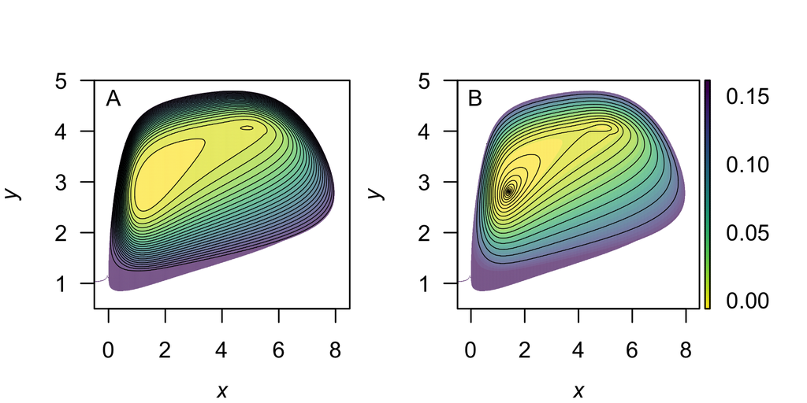

Figure 4: A contour plot of the of the quasi-potential of System @ref(eq:ex1). Yellow corresponds to low values of the quasi-potential, and purple to high values. The `c.parm` parameter in `QPContour()` can be used to generate non-equal contour spacing (e.g., for finer resolution near equilibria). The default creates evenly spaced contour lines ((A); `c.parm = 1`). In (B), contour lines are concentrated at the bottom of the basin (`c.parm = 5`). Default plot colors are generated from package [*viridis*](https://CRAN.R-project.org/package=viridis) (Garnier 2016), by setting `col.contour = viridis(n = 25, option = "D")` in `QPContour()`.